# Homework 3

Last complied on March 11, 2024

1. Refer to the Kohavi et al (2009) article. Look at the example in Section 3.2.1 on page 153. Verify the sample size calculations using the Z statistics for $\alpha/2$=0.025 and $\beta$=0.2 and this formula:
   $$n_1=\frac{2(Z_{(1-\alpha/2)}+Z_{(1-\beta)}
   )^2\times \sigma^2}{\Delta^2}$$

They give an approximation in their example. Compute for both responses, userspend and conversion rate. Explain the difference between these sample size numbers.

```r
# Users to achieve 80% power with 5% change in user spend
((2*(1.96 + .7881)^2) * 30^2)/(3.75 * 0.05)^2
```

```
## [1] 386665.1
```

Now looking at a 5% change in conversion rate:

```r
# Users to achieve 80% power with 5% change in conversion rate
((2*(1.96 + .7881)^2) * (0.05*(1-0.05)))/(0.05*0.05)^2
```

```
## [1] 114791.2
```

The difference in the sample size numbers comes from the use of the Z scores in our equation. The book uses a simpler formula using 16 * the standard deviation divided by the difference squared. Our formula calculates the required sample sizes difference which explains the slights differences.

Investigate the following relationships in terms of statistical power to detect a difference between two means. For example, below is a plot that illustrates how changing effect size (mean difference) changes the power. Using this framework, investigate the following relationships. Use power=0.8, sd=30, n=100, and $\alpha$=0.05 unless otherwise stated.

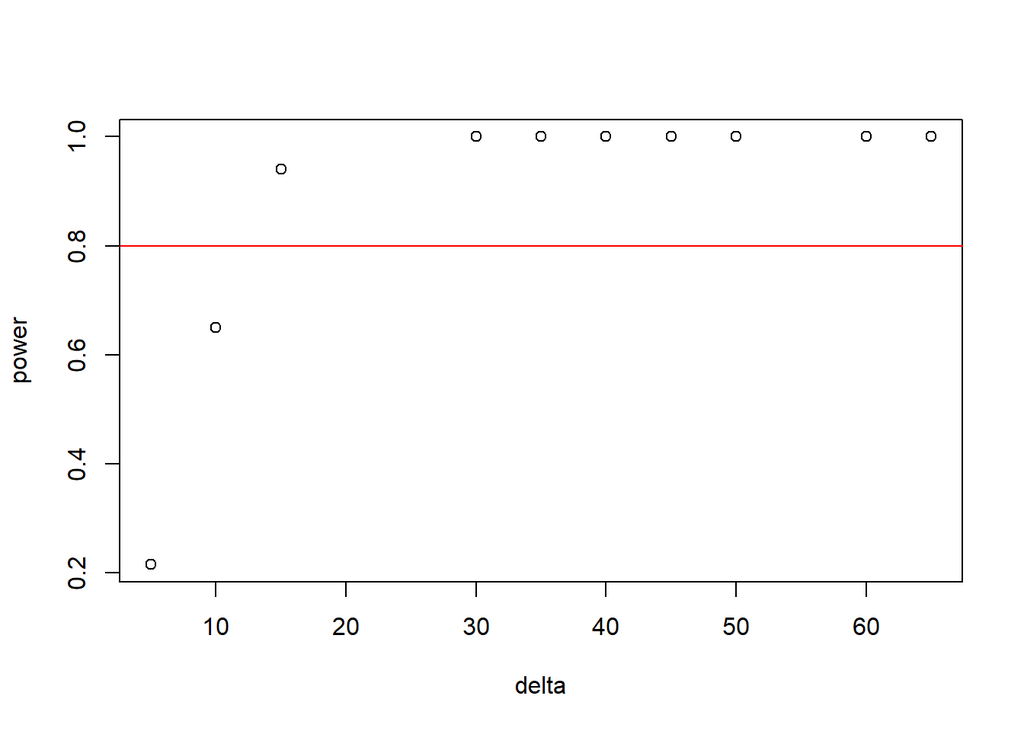

```r
results<-c()
d<-c(5, 10, 15, 30, 35, 40, 45, 50, 60, 65)
for(i in 1:length(d)){
  results[i]<-power.t.test(delta=d[i], n=100, sd=30, sig.level=0.05, power=NULL)$power
}

plot(d, results, xlab="delta", ylab="power")
abline(h=0.8, col="red")
```

2. What happens to the power when the standard deviation increases and nothing else changes?

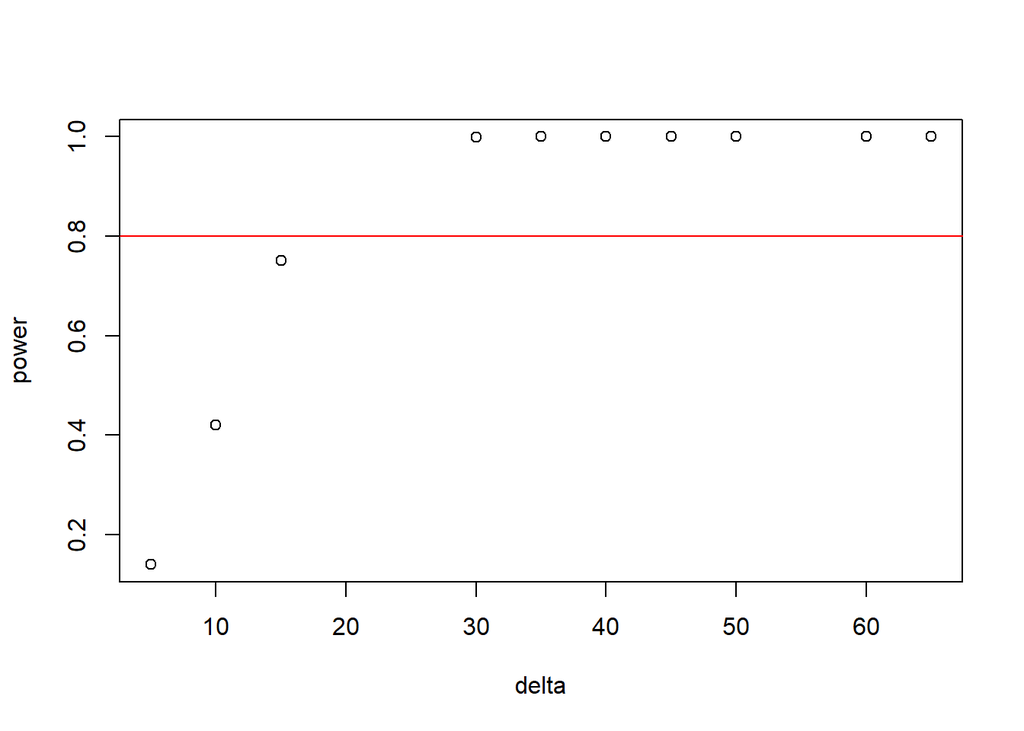

```r
results<-c()
d<-c(5, 10, 15, 30, 35, 40, 45, 50, 60, 65)
for(i in 1:length(d)){
  results[i]<-power.t.test(delta=d[i], n=100, sd=40, sig.level=0.05, power=NULL)$power
}

plot(d, results, xlab="delta", ylab="power")
abline(h=0.8, col="red")
```

Power decreases

3. What happens to the power when we increase sample size and nothing else changes?

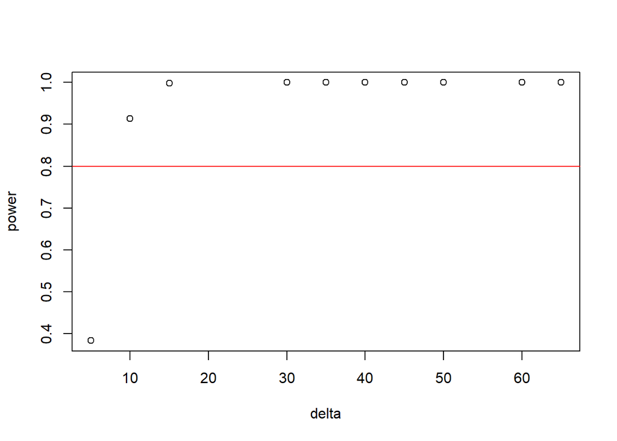

```r
results<-c()
d<-c(5, 10, 15, 30, 35, 40, 45, 50, 60, 65)
for(i in 1:length(d)){
  results[i]<-power.t.test(delta=d[i], n=200, sd=30, sig.level=0.05, power=NULL)$power
}

plot(d, results, xlab="delta", ylab="power")
abline(h=0.8, col="red")
```

Power increases

4. What happens to the power when change the $\alpha$ level and nothing else changes?

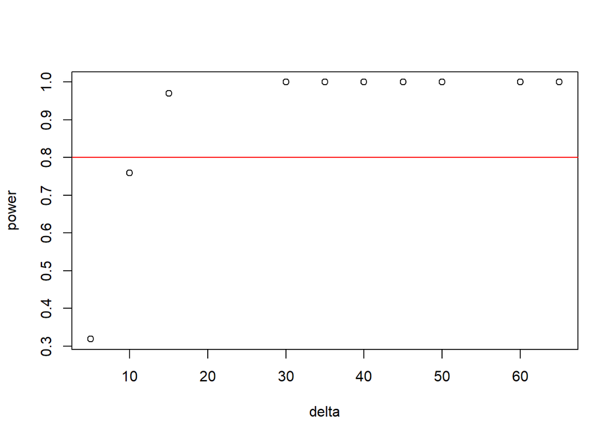

```r
results<-c()
d<-c(5, 10, 15, 30, 35, 40, 45, 50, 60, 65)
for(i in 1:length(d)){
  results[i]<-power.t.test(delta=d[i], n=100, sd=30, sig.level=0.1, power=NULL)$power
}

plot(d, results, xlab="delta", ylab="power")
abline(h=0.8, col="red")
```

When the $\alpha$ level goes up, power increases

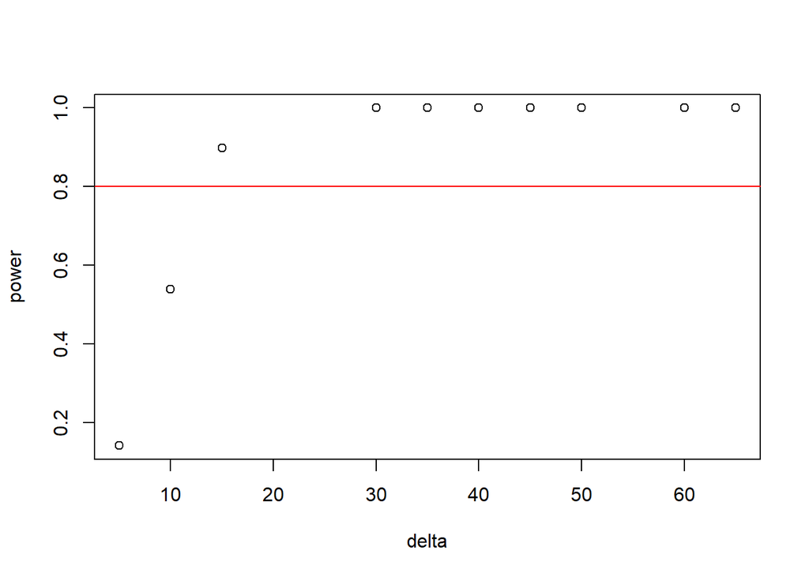

```r
results<-c()
d<-c(5, 10, 15, 30, 35, 40, 45, 50, 60, 65)
for(i in 1:length(d)){
  results[i]<-power.t.test(delta=d[i], n=100, sd=30, sig.level=0.025, power=NULL)$power
}

plot(d, results, xlab="delta", ylab="power")
abline(h=0.8, col="red")
```

When the $\alpha$ level decreases, power decreases

5. What happens to the sample size when we hold power=0.8 and increase the effect size?

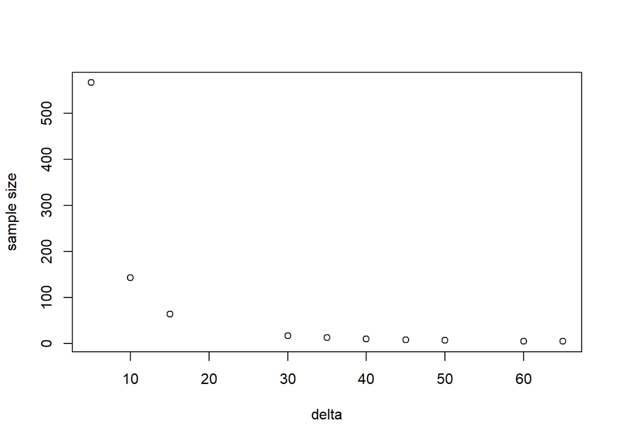

```r
results<-c()
d<-c(5, 10, 15, 30, 35, 40, 45, 50, 60, 65)
for(i in 1:length(d)){
  results[i]<-power.t.test(delta=d[i], n=NULL, sd=30, sig.level=0.05, power=0.8)$n
}

plot(d, results, xlab="delta", ylab="sample size")
```

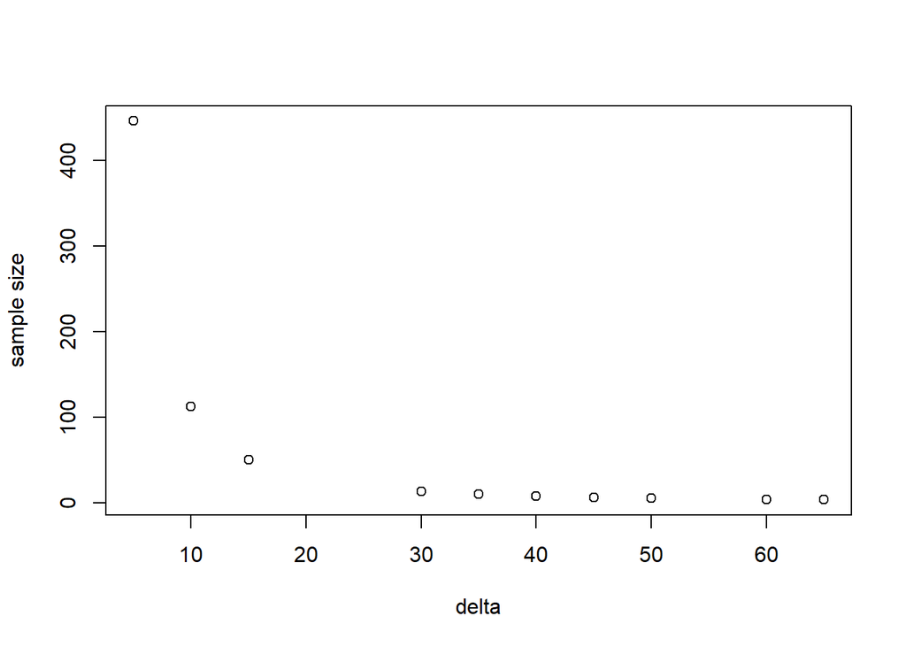

```r
results<-c()
d<-c(5, 10, 15, 30, 35, 40, 45, 50, 60, 65)
for(i in 1:length(d)){
  results[i]<-power.t.test(delta=d[i], n=NULL, sd=30, sig.level=0.1, power=0.8)$n
}

plot(d, results, xlab="delta", ylab="sample size")
```

Sample size decreases

6. How many emails will you have to send to each group to achieve this percentage increase?

```r
power.prop.test(n=NULL, p1=0.23, p2=0.28, sig.level = 0.05, power=.8)
```

```
##
##      Two-sample comparison of proportions power calculation
##
##               n = 1191.693
##              p1 = 0.23
##              p2 = 0.28
##       sig.level = 0.05
##           power = 0.8
##     alternative = two.sided
##
## NOTE: n is number in *each* group
```

You would have to send at least 1,192 emails to each group to achieve this percentage increase

7. Is this a feasible increase to target? Why or why not?

Yes, as this is using a feasible significane level and power, and sending 2,384 emails to a large university is not unfeasible

In a hypothetical case, a promotion for a hair care produce was sent to some members of a buyers club. Purchases were then recorded for both the members who got the promotion and those who did not. Use the data “Hair-Care-Product.csv” to answer the following questions.

```r
df<-read.csv("https://raw.githubusercontent.com/losiewbw/ISA633/main/Hair-Care-Product.csv")
head(df)
```

```
##   Purchase Age Hair.Color U.S..Region Validation Promotion_ord Gender_ord
## 1        0  25      Black   Southwest          1             1          0
## 2        0  30      Black   Northwest          1             0          0
## 3        0  45        Red   Northeast          1             0          0
## 4        0  35      Blond   Southwest          0             0          0
## 5        0  33      Brown   Southwest          0             1          0
## 6        0  35      Brown   Northeast          0             0          1
##   Residence_ord
## 1             1
## 2             1
## 3             0
## 4             1
## 5             1
## 6             1
```

```r
str(df)
```

```
## 'data.frame':    10000 obs. of  8 variables:
##  $ Purchase     : int  0 0 0 0 0 0 0 0 0 0 ...
##  $ Age          : int  25 30 45 35 33 35 25 52 21 24 ...
##  $ Hair.Color   : chr  "Black" "Black" "Red" "Blond" ...
##  $ U.S..Region  : chr  "Southwest" "Northwest" "Northeast" "Southwest" ...
##  $ Validation   : int  1 1 1 0 0 0 0 0 1 0 ...
##  $ Promotion_ord: int  1 0 0 0 1 0 0 0 0 0 ...
##  $ Gender_ord   : int  0 0 0 0 0 1 0 1 0 1 ...
##  $ Residence_ord: int  1 1 0 1 1 1 1 1 0 1 ...
```

8. What is the purchase propensity for those who did and did not received the promotion?

```r
# Purchase propensity for those who received the promotion
mean(df$Purchase[df$Promotion_ord == 1])
```

```
## [1] 0.01607717
```

```r
# Purchase propensity for those who did not receive the promotion
mean(df$Purchase[df$Promotion_ord == 0])
```

```
## [1] 0.006369427
```

9. Partition the data into training and validation using the Validation column. Fit an uplift model using a random forest. Do this in Python using the `reticulate` package or copy these questions to a Jupiter notebook and turn in another separate html file.
10. Find the top 10 persuadable in the data set describe these people.

Please view separate HTML file